# Single seed microbiota: assembly and transmission from parent plant to seedling

Chesneau et al., 2021

21/05/2021

# Before you start

This script has been made on R version 4.0.0 (and Rstudio 1.2.5019)

```r
R.version
```

```
##                _
## platform       x86_64-w64-mingw32
## arch           x86_64
## os             mingw32
## system         x86_64, mingw32
## status
## major          4
## minor          0.0
## year           2020
## month          04
## day            24
## svn rev        78286
## language       R
## version.string R version 4.0.0 (2020-04-24)
## nickname       Arbor Day
```

```r
#Load theme set
library(ggplot2)
theme_set(theme_bw())
```

# Data information

**Project:** ANR SEEDS

**Experiment 3 :** “Community dynamics during emergence”

**Factors :**

- Plant species : bean (*Phaseolus vulgaris*) and radish (*Raphanus sativus*)
- Habitats sampled : Seeds and seedlings
- Seeds were collected from 5 plants, 8 fruits per plants, 4 seeds per fruit
- DNA extraction : MN Food on CFU - after enrichment on TSA10%
- Primers : v4 region of 16S rRNA gene (Caporaso et al., 2011) and *gyrB* (Barret et al., 2015)
- 2 sequencing run (MiSeq v2 - 500 cycles )

## 1 - Load dataset

### 1.1 - Full dataset

Select only the third dataset

### 1.2 - Subset by plant species

Bean and radish

## 2 - Seed 2 seedling at the individual level

Here we assessed the dynamics of the seed microbiota during emergence for each seed-seedling

We first assess the number of sequences per sample

We next performed rarefaction curves

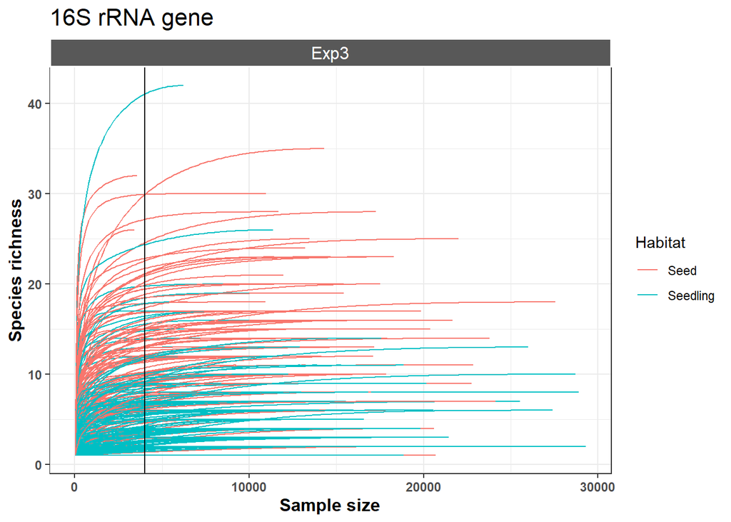

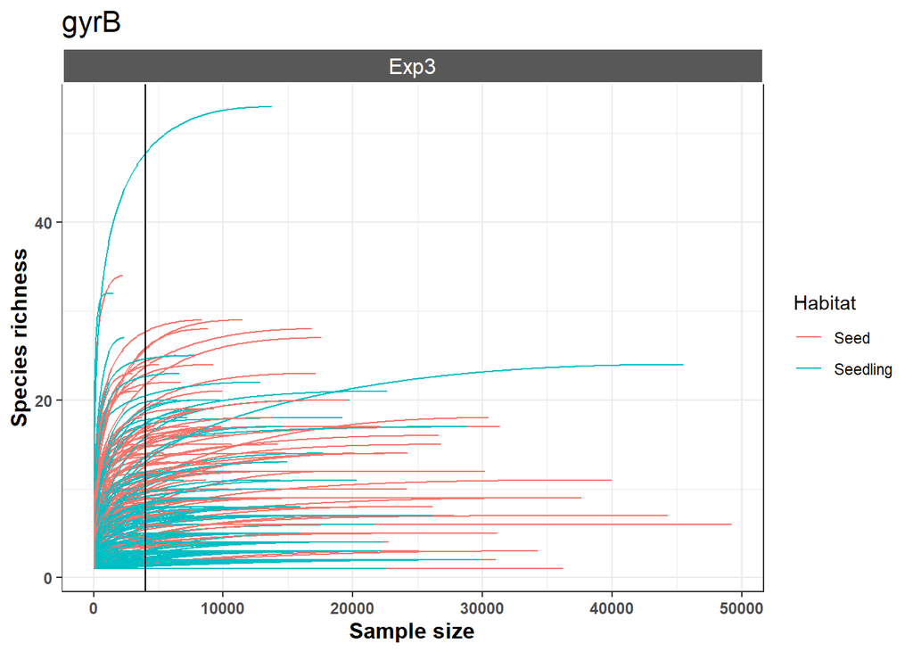

### 2.1 - Richness

In this part we used rarefy data :

- **16S** : 4,000 reads per sample
- **gyrB** : 4,000 reads per sample

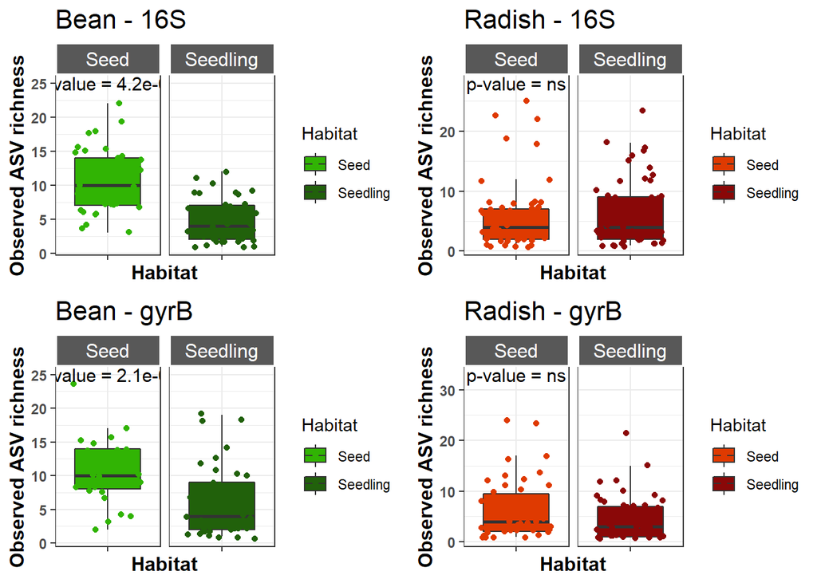

### 2.2 - Phylogenetic diversity

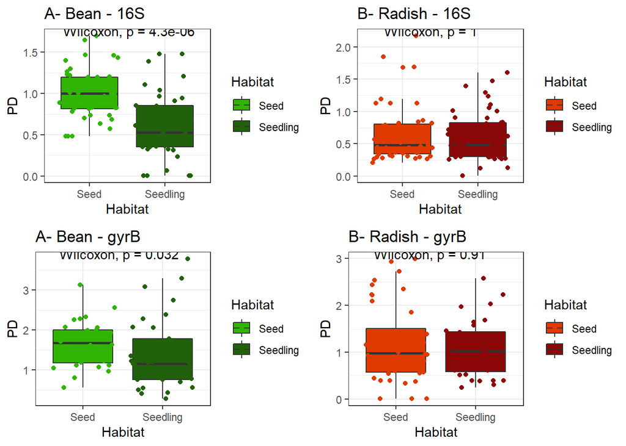

### 2.3 - Population size

We evaluated the population size for each individual seeds and seedling. And for our axenic system used to grow seedling.

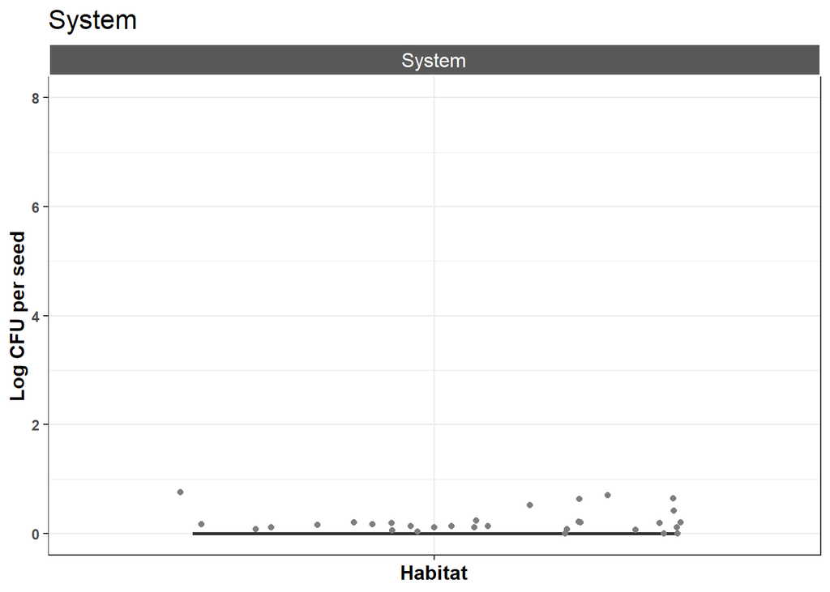

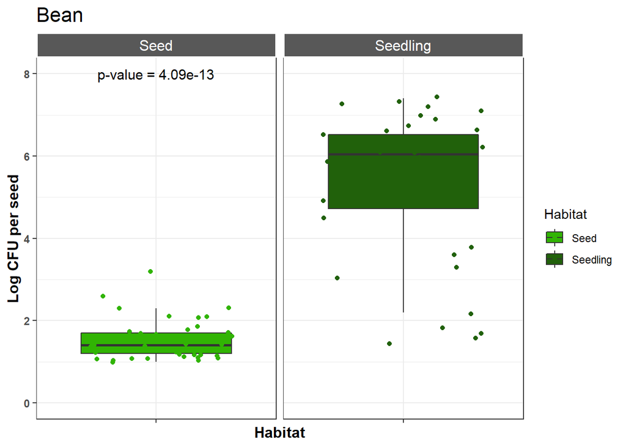

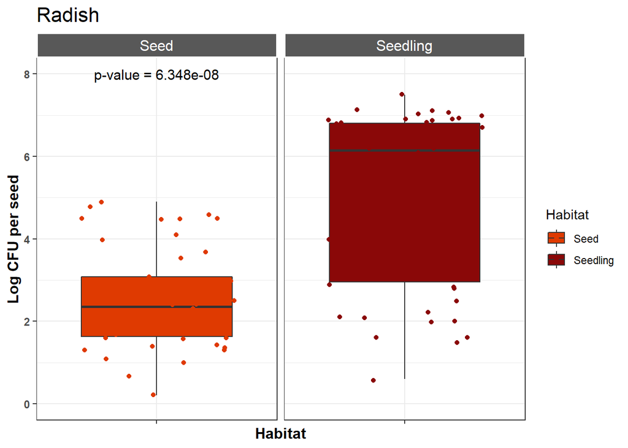

### 2.4 - Taxonomy

Here we merged our samples per habitats to evaluate the taxonomic composition.

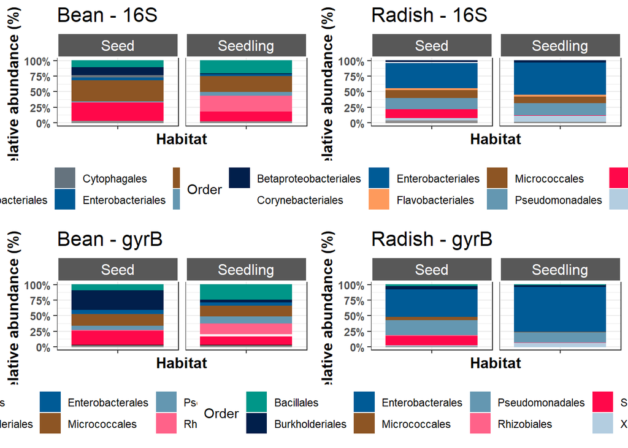

### 2.5 - UpSet

We estimated how many taxa were specifically affiliated to the seed, seedling or both.

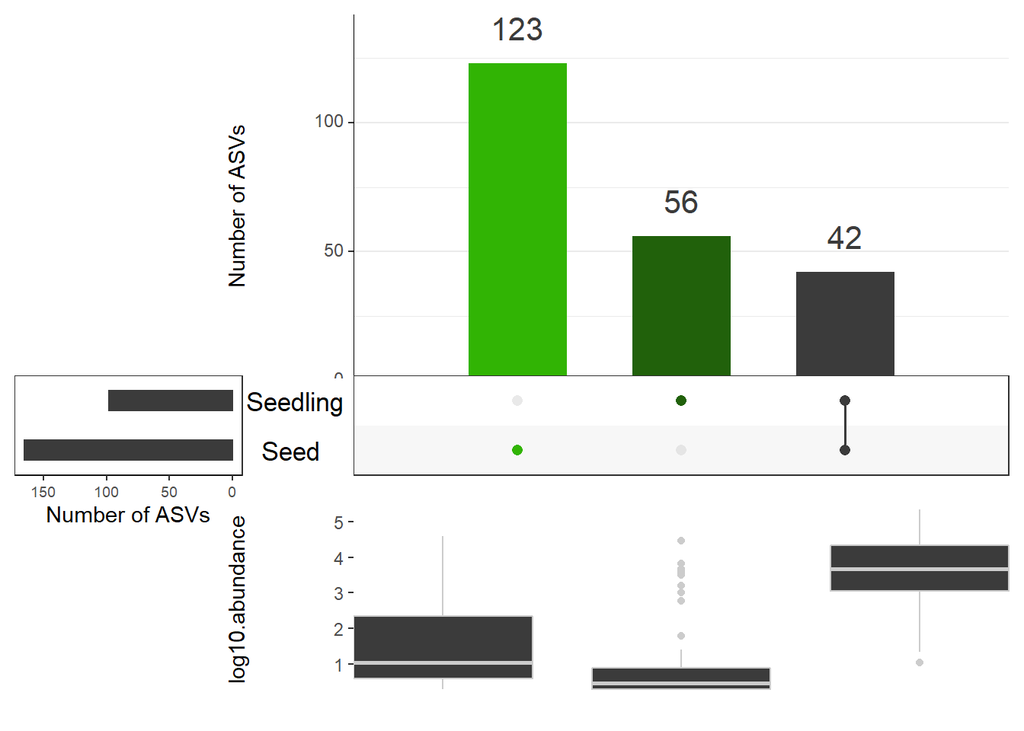

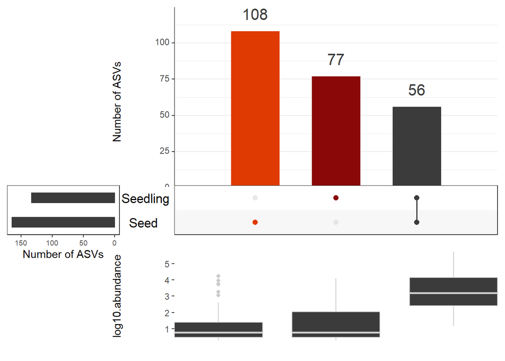

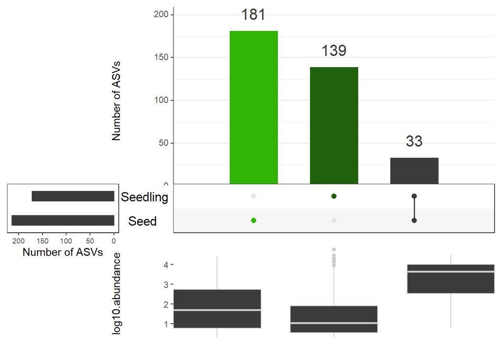

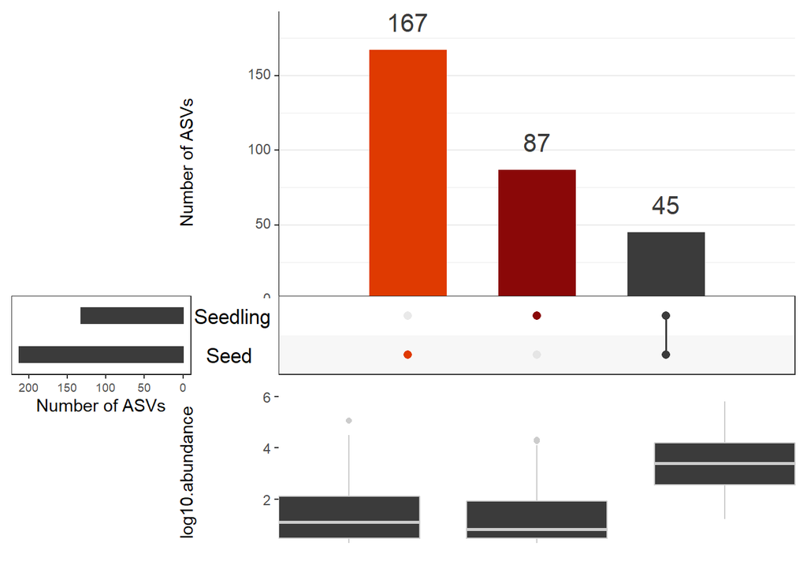

### 2.6 - Rank abundance

#### 2.6.1 - Measure rank abundance

We assessed rank abundance of seeds and seedlings.

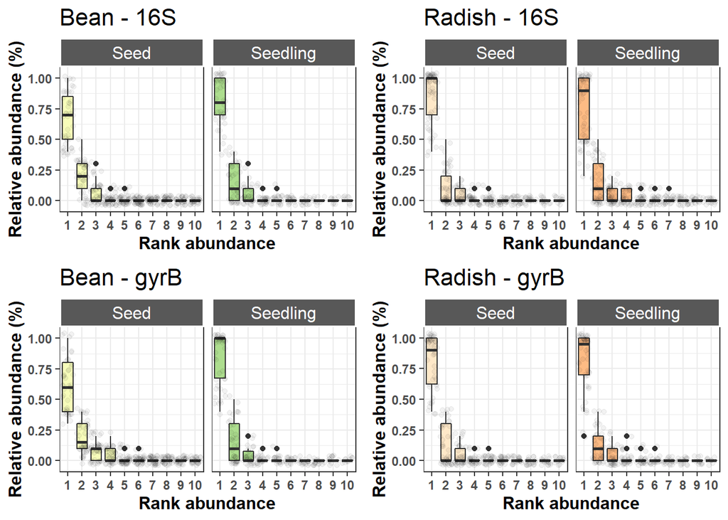

#### 2.6.2 - Correlation abundance seed vs seedling

We estimated abundance of each taxa in an individual plant in seed and the corresponding future seedling.

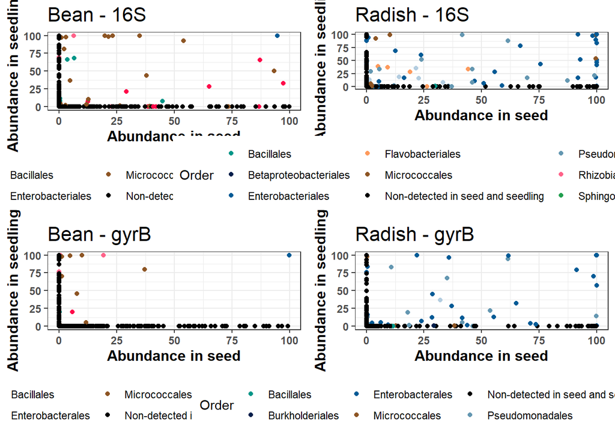

## 3 - Germination

We selected only seed samples in order to evaluate differences in microbiota composition and structure for germinated and non-germinated seeds.

### 3.1 - Richness

In this part we used rarefy data :

- **16S** : 4,000 reads per sample
- **gyrB** : 4,000 reads per sample

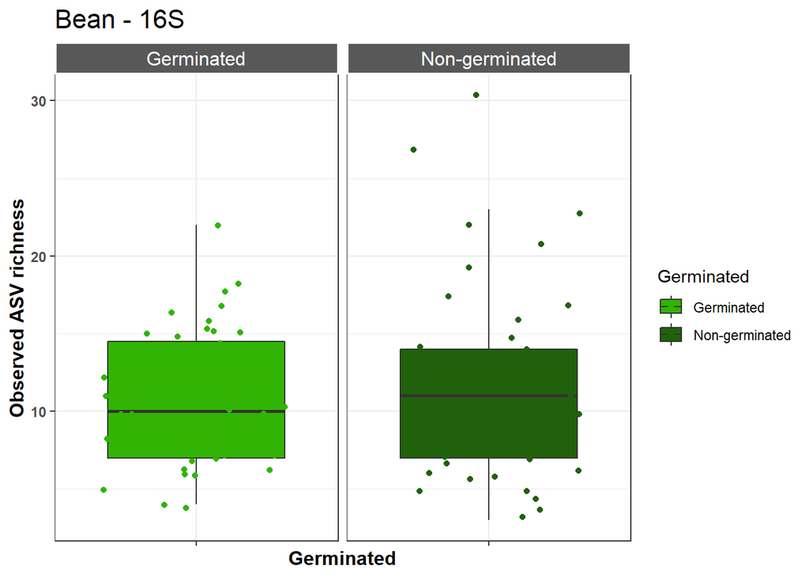

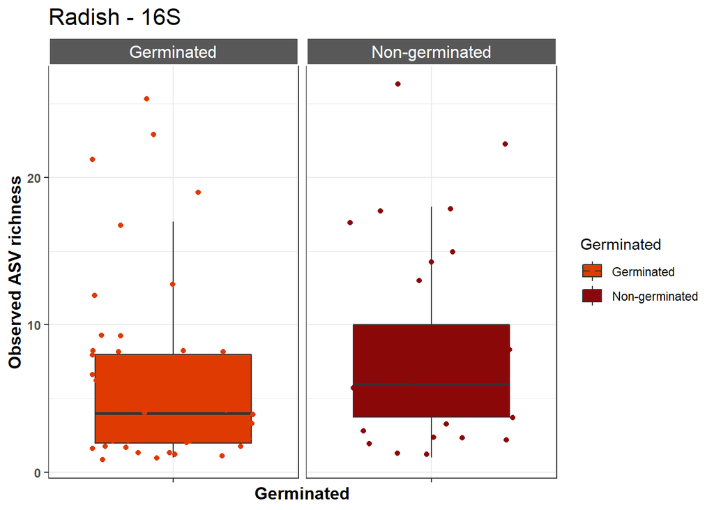

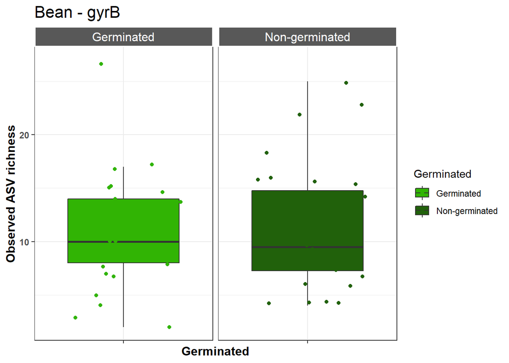

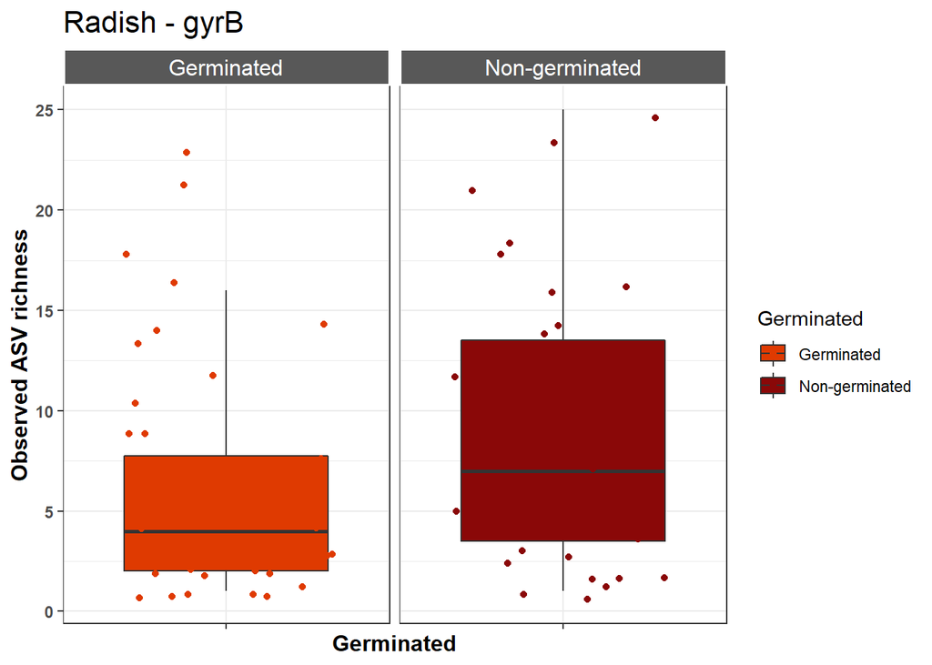

### 3.2 - Population size

We estimated the population size for germinated and non-germinated seeds.

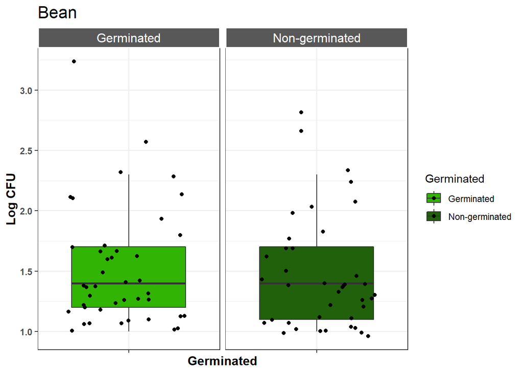

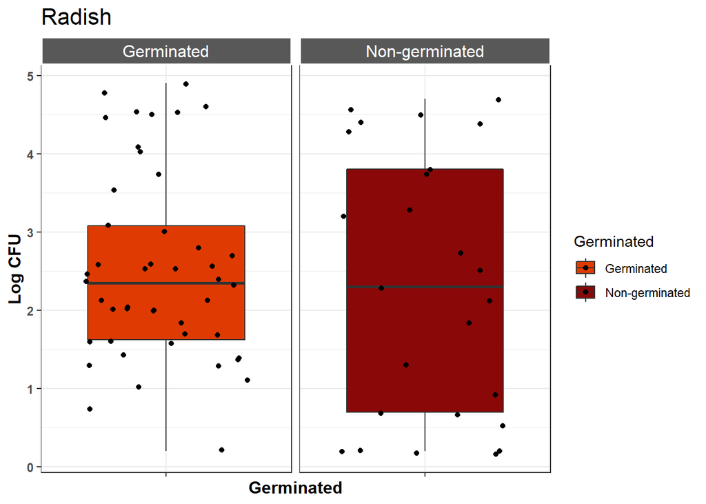

### 3.3 - Taxonomy

We estimated the taxonomic composition affiliated with germinated and non-germinated seeds.

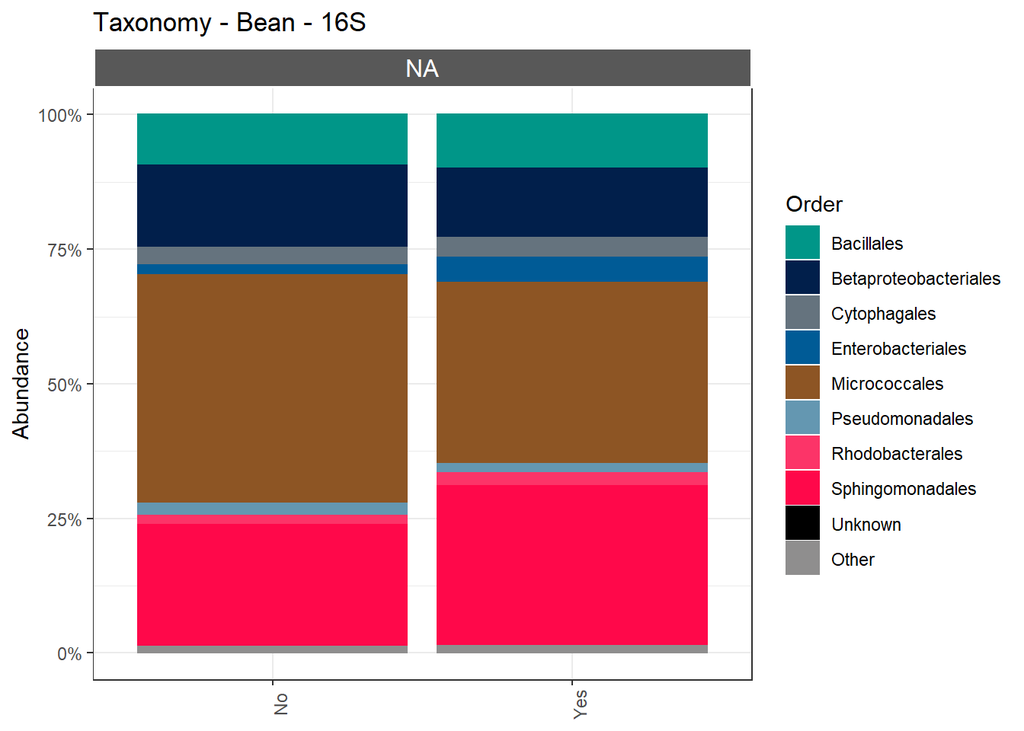

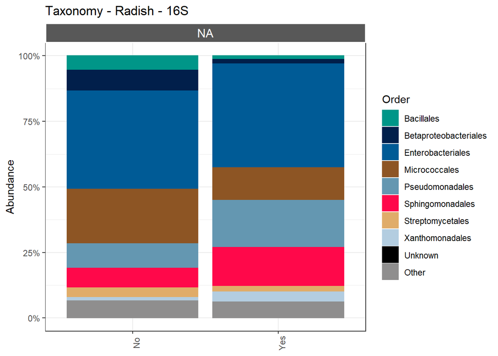

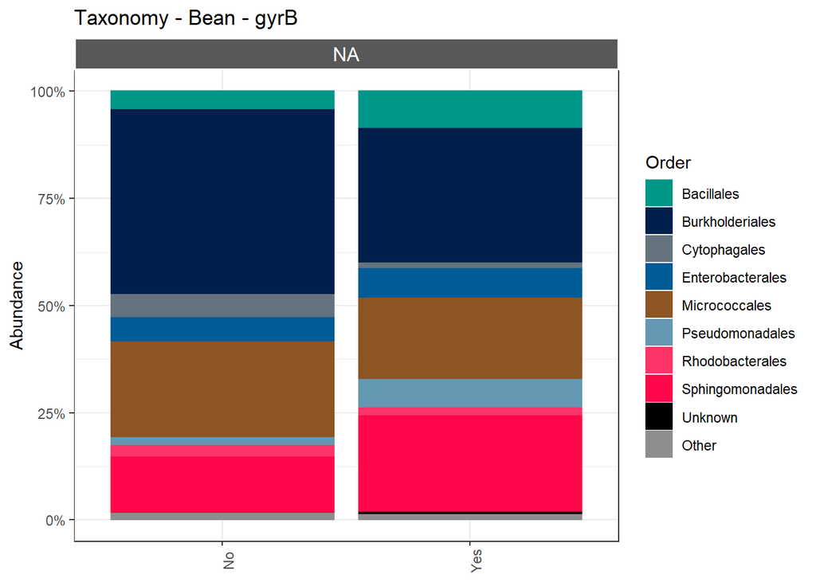

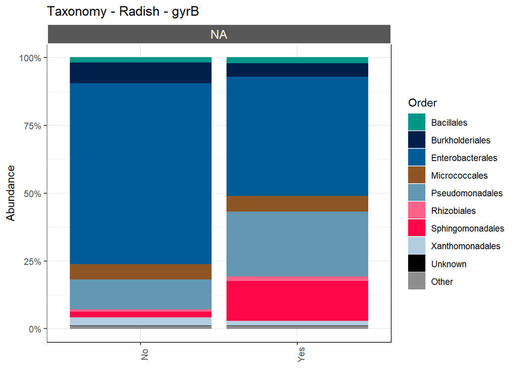

### 3.4 - DeSeq2

Identification of specific ASVs associated to germinating and non-germinating seeds was estimated with DeSeq2.

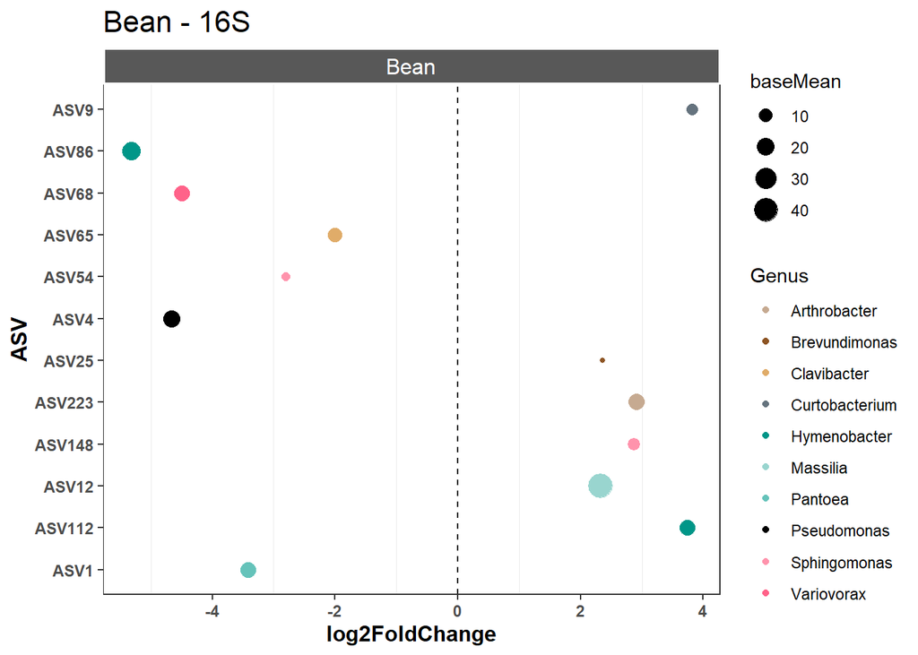

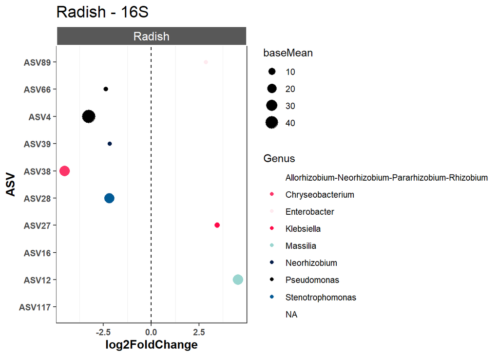

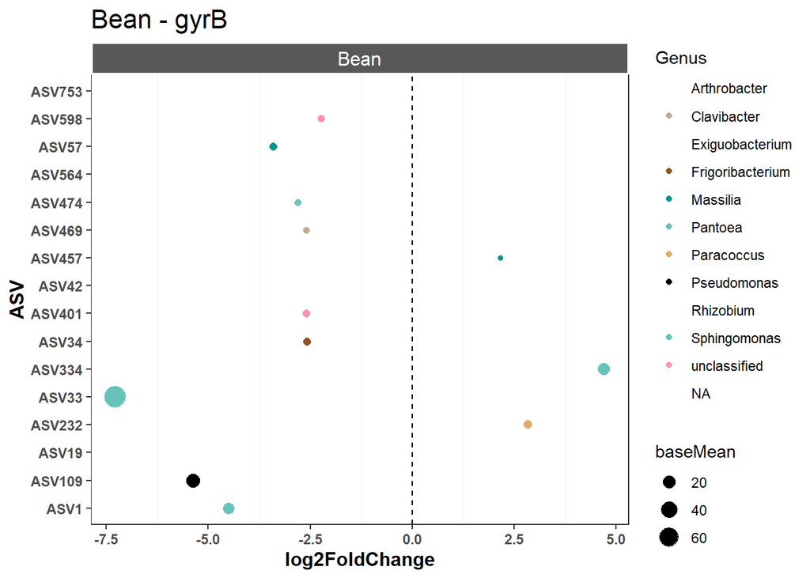

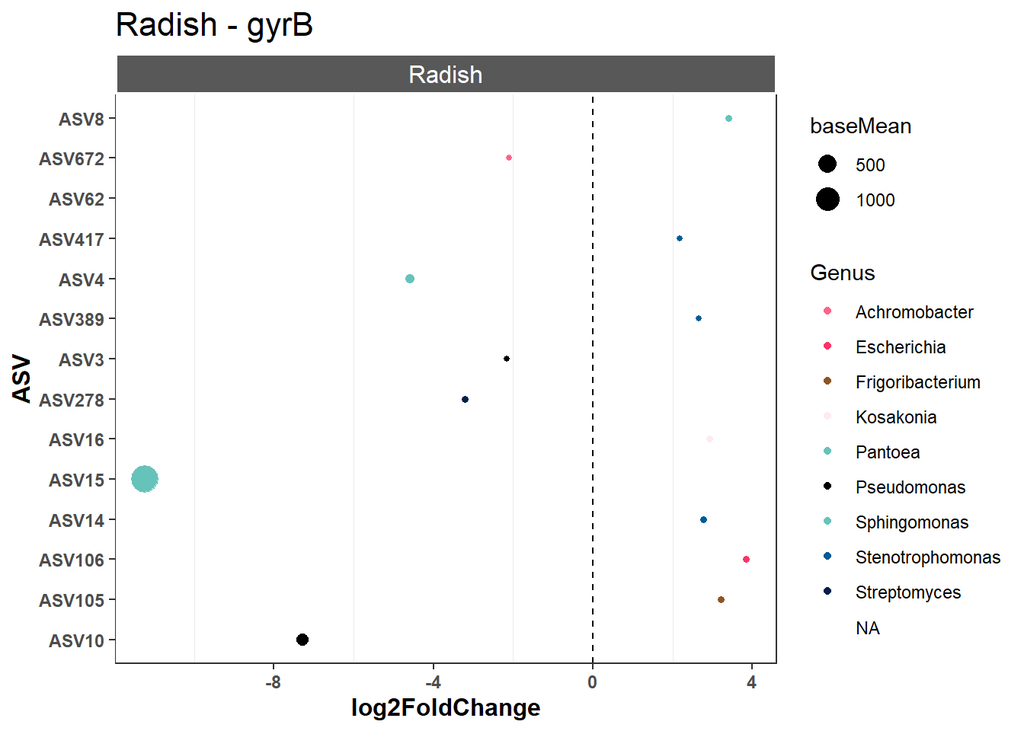

## 4 - Normal vs abnormal seedlings

We evaluate differences in seedling phenotype (noraml or abnormal seed mat&met for more information) according to seed microbiota.

### 4.1 - Richness

Select seed and its corresponding seedling only

In this part we used rarefy data :  
* **16S** : 4,000 reads per sample  
* **gyrB** : 4,000 reads per sample

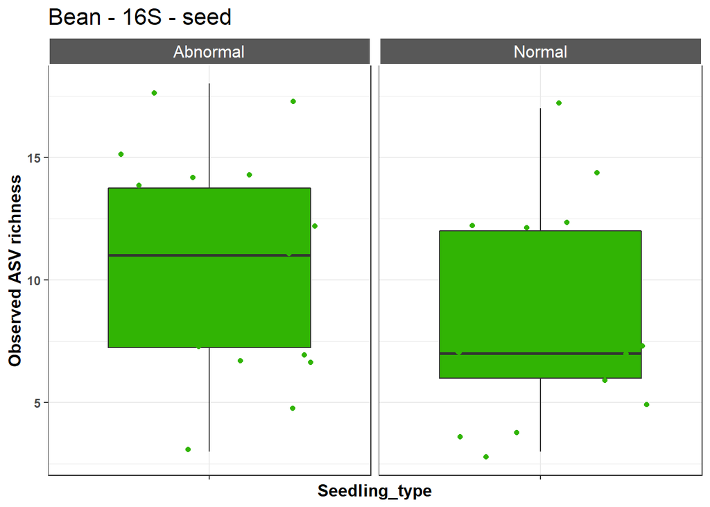

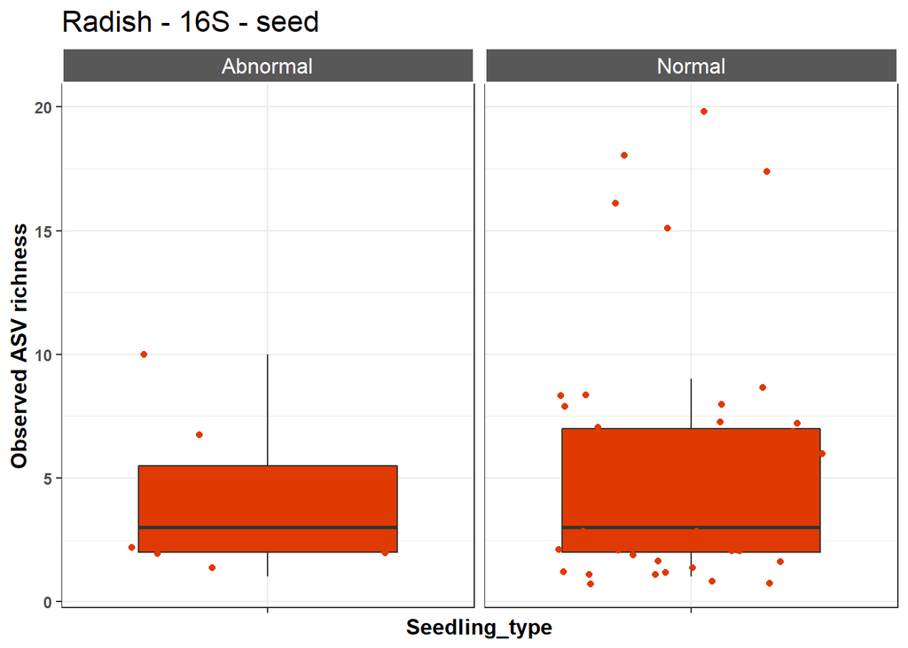

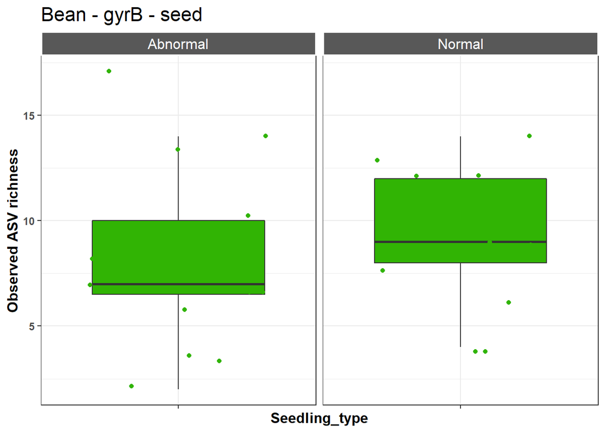

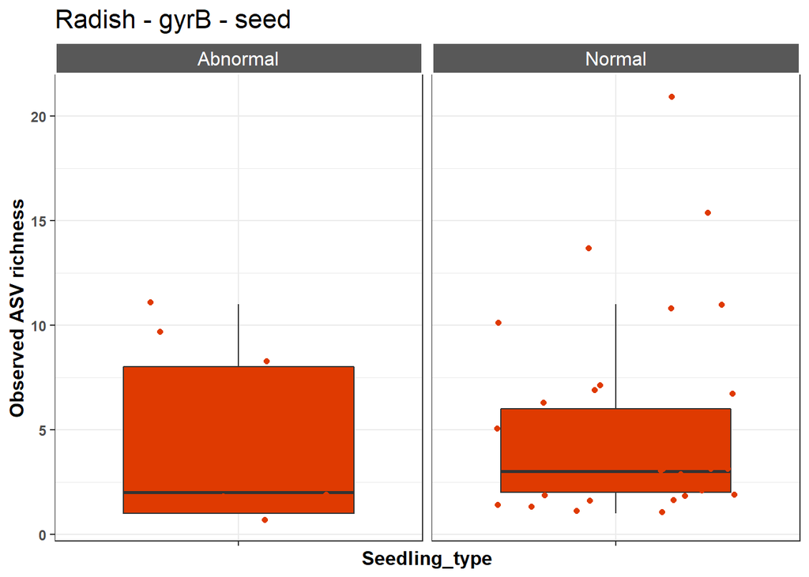

### 4.2 - Population size

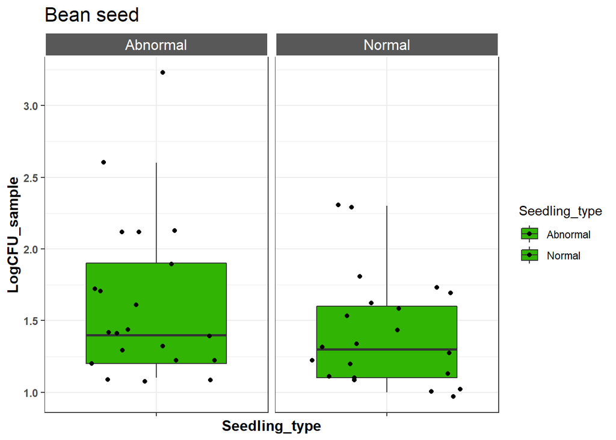

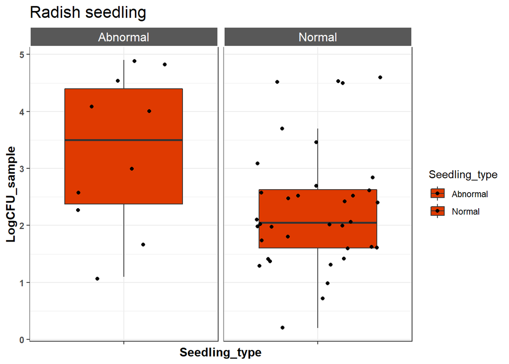

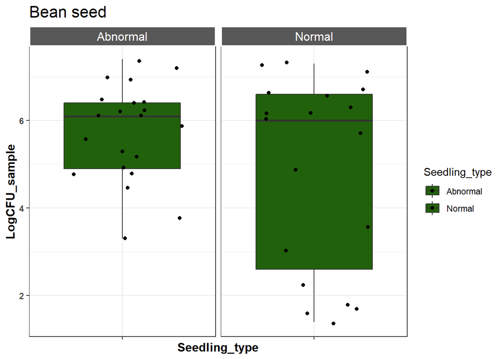

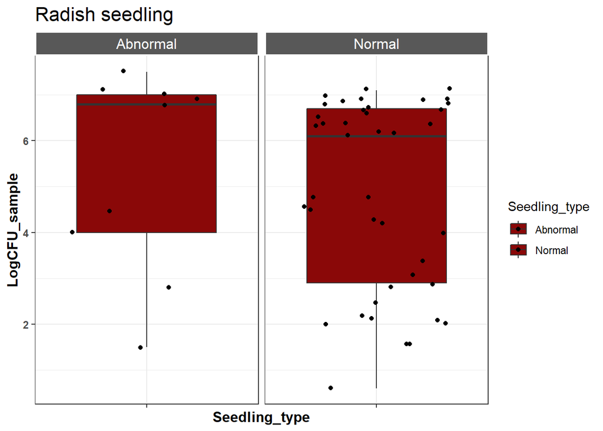

### 4.3 - DeSeq2 normal vs abnormal seedling.

Here we assessed if the RA of some specific ASV could be associated with abnormal and normal seedling with DeSeq2.  
We only performed this analysis with bean due to balanced sampling of normal and abnormal seedlings.

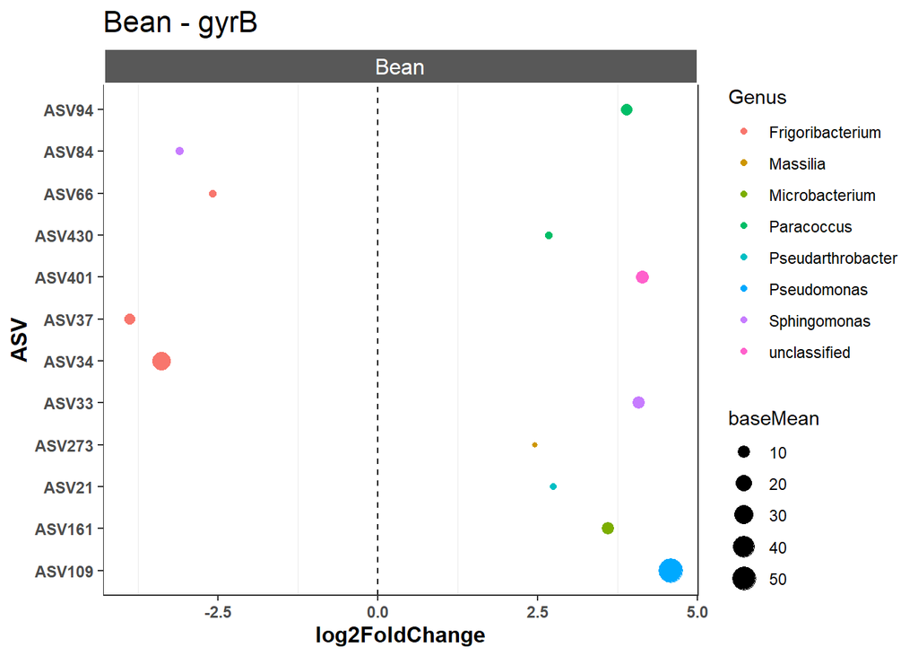

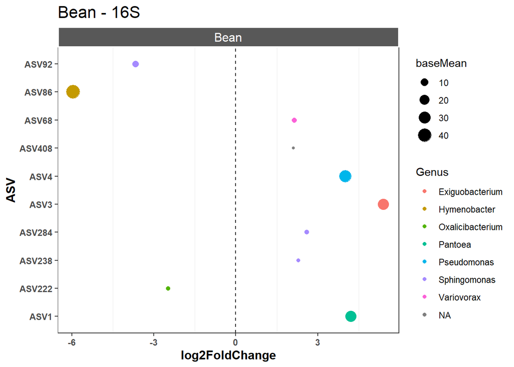

## 5 - ASV plant inoculation

### 5.1 - Seedling phenotype

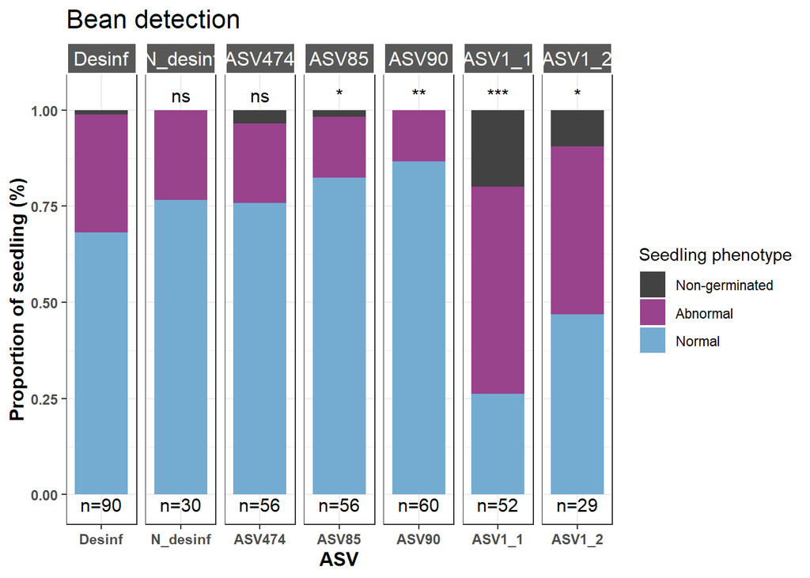

### 5.2 - Statistiques

Statistic tests were performed using chi2, comparing Decinfected seeds with tested conditions.

```
##
##  Pearson's Chi-squared test
##
## data:  Stats_D_vs_B056
## X-squared = 23.589, df = 1, p-value = 1.192e-06
```

```
##    T_Desinf     B056
## PN 45.71154 45.71154
## PA 44.28846 44.28846
```

```
##
##  Pearson's Chi-squared test
##
## data:  Stats_D_vs_B056
## X-squared = 23.589, df = 1, p-value = 1.192e-06
```

```
##    T_Desinf     B056
## PN 45.71154 45.71154
## PA 44.28846 44.28846
```

```
##
##  Pearson's Chi-squared test
##
## data:  Stats_D_vs_B175
## X-squared = 5.5387, df = 1, p-value = 0.0186
```

```
##    T_Desinf     B175
## PN 54.27586 54.27586
## PA 35.72414 35.72414
```

```
##
##  Pearson's Chi-squared test
##
## data:  Stats_D_vs_B029
## X-squared = 2.1782, df = 1, p-value = 0.14
```

```
##    T_Desinf     B029
## PN 66.35714 66.35714
## PA 23.64286 23.64286
```

```
##
##  Pearson's Chi-squared test
##
## data:  Stats_D_vs_B038
## X-squared = 5.6467, df = 1, p-value = 0.01749
```

```
##    T_Desinf     B038
## PN 68.76786 68.76786
## PA 21.23214 21.23214
```

```
##
##  Pearson's Chi-squared test
##
## data:  Stats_D_vs_B078
## X-squared = 8.2286, df = 1, p-value = 0.004124
```

```
##    T_Desinf B078
## PN       70   70
## PA       20   20
```

# End of script

Chesneau et al., 2021  
title: “Single seed microbiota: assembly and transmission from parent plant to seedling”